# Test a Perceptual Phenomenon

### Analyzing the Stroop Effect

Perform the analysis in the space below. Remember to follow [the instructions](https://docs.google.com/document/d/1-OkpZLjG_kX9J6LIQ5IltsqMzVWjh36QpnP2RYpVdPU/pub?embedded=True) and review the [project rubric](https://review.udacity.com/#!/rubrics/71/view) before submitting. Once you've completed the analysis and write-up, download this file as a PDF or HTML file, upload that PDF/HTML into the workspace here (click on the orange Jupyter icon in the upper left then Upload), then use the Submit Project button at the bottom of this page. This will create a zip file containing both this .ipynb doc and the PDF/HTML doc that will be submitted for your project.

(1) What is the independent variable? What is the dependent variable?

#### Independent variable : It contains both the Congruent ( when the word name and color are same ) and Incongruent ( when the word name and color are different ).

#### dependent variable : It contains the reaction time (RT) to notice the name of the font color of the word.

(2) What is an appropriate set of hypotheses for this task? Specify your null and alternative hypotheses, and clearly define any notation used. Justify your choices.

H0 (Null Hypothesis): The difference of color to word will have no effect on the reaction time to recognize and say the color, which can be mathematically represented as

```
H0: μC = μI
```

H1 (Alternate Hypothesis): The difference of color to word will increase the reaction time to recognize and say the color, which can be mathematically represented as

```
HA:  μI > μC
```

#### I will chose the t-test rather than the z-test because :

1) The samples I have are less than 30 wich is satisfied with t-test

2) The population standard deviation is not defined

(3) Report some descriptive statistics regarding this dataset. Include at least one measure of central tendency and at least one measure of variability. The name of the data file is 'stroopdata.csv'.

```python
# Perform the analysis here
%matplotlib inline

import matplotlib.pyplot as plt
import pandas as pd
import numpy as np
from scipy import stats


spd = pd.read_csv("stroopdata.csv")
spd.head()
```

|  | Congruent | Incongruent |
| --- | --- | --- |
| 0 | 12.079 | 19.278 |
| 1 | 16.791 | 18.741 |
| 2 | 9.564 | 21.214 |
| 3 | 8.630 | 15.687 |
| 4 | 14.669 | 22.803 |

```python
#use shape to know number of rows and columns in the data set
spd.shape
```

```
(24, 2)
```

```python
#use describe to see the descriptive stats
spd.describe()
```

|  | Congruent | Incongruent |
| --- | --- | --- |
| count | 24.000000 | 24.000000 |
| mean | 14.051125 | 22.015917 |
| std | 3.559358 | 4.797057 |
| min | 8.630000 | 15.687000 |
| 25% | 11.895250 | 18.716750 |
| 50% | 14.356500 | 21.017500 |
| 75% | 16.200750 | 24.051500 |
| max | 22.328000 | 35.255000 |

```python
# median / 50% values
congruent = spd['Congruent']
incongruent = spd['Incongruent']
congruent.median(), incongruent.median()
```

```
(14.3565, 21.0175)
```

```python
# use std to figure out the standard deviation
congruent = spd['Congruent']
incongruent = spd['Incongruent']
congruent.std(), incongruent.std()
```

```
(3.5593579576451955, 4.7970571224691376)
```

#### measure of central tendency:

Read the csv file then we try to know what is the sample size Sample Size : 24 mean of sample size for "Congruent 14.051125" and " Incongruent 22.015917 "

i will choose median to see the better representation of central tendency. "Congruent 14.3565" and " Incongruent 21.0175 "

#### measure of variability:

last thing i will caculate the standard deviation "Congruent 3.5593579576451955" and " Incongruent 4.7970571224691376 "

(4) Provide one or two visualizations that show the distribution of the sample data. Write one or two sentences noting what you observe about the plot or plots.

```
Text(0,0.5,'Frequency')
```

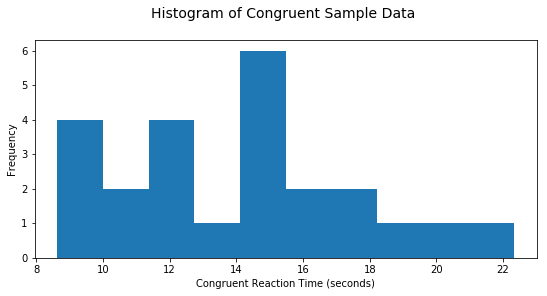

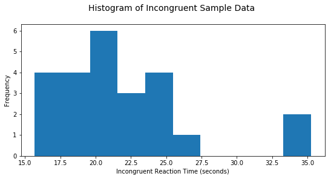

```python
# Build the visualizations here
 #creat histogram then set size and x , y label
plt.figure(figsize=(9, 4))
plt.hist(congruent)
plt.title('Histogram of Congruent Sample Data \n', fontsize=14)
plt.xlabel("Congruent Reaction Time (seconds)")
plt.ylabel("Frequency")

plt.figure(figsize=(9, 4))
plt.hist(incongruent)
plt.title('Histogram of Incongruent Sample Data \n', fontsize=14)
plt.xlabel("Incongruent Reaction Time (seconds)")
plt.ylabel("Frequency")
```

(5) Now, perform the statistical test and report your results. What is your confidence level or Type I error associated with your test? What is your conclusion regarding the hypotheses you set up? Did the results match up with your expectations? **Hint:** Think about what is being measured on each individual, and what statistic best captures how an individual reacts in each environment.

```python
# Perform the statistical test here
tvalue,pvalue = stats.ttest_rel(spd['Incongruent'],spd['Congruent'],axis=0)
tvalue,pvalue
```

```
(8.020706944109957, 4.1030005857111781e-08)
```

Confidence Interval = 95%

degrees of freedom = 23 " we have 24 samples and 24-1 = 23 "

calculated t-value = 8.02

p-value = 0.00000004

```python
stats.t.ppf(.95,23)
```

```
1.7138715277470473
```

one-tailed critical statistic value = 1.714

### Result :

First thing the t-value is related to the sample of 24 participants , because we want to know if there is statistically significant mean difference between the (RT) between the congruent and incongruent condition. And then we assume that the confidence level is 95% , and the degree of freedom is 23 , then I calculated the critical statistic value for a one-tailed test is 1.714.

The calculated t-value for the difference between the congruent and incongruent conditions is 8.02. The calculated t-value is greater than the critical t-value which is 1.714. So , the null hypothesis is rejected. And we will accept the Alternative hypothesis.

(6) Optional: What do you think is responsible for the effects observed? Can you think of an alternative or similar task that would result in a similar effect? Some research about the problem will be helpful for thinking about these two questions!